# GH 536 - Key Homework 2

Chris Troeger

February 3, 2022

# Question 1: Logistic and log binomial models

## 1.1 What type of regression model was used in the [publication](https://journals.plos.org/plosntds/article?id=10.1371/journal.pntd.0003743#sec019)? List the independent variables and how they were coded. What variables were used as outcomes?

The Authors controlled for age of children (*age_at_entry*), maternal education (not sure which variable this is), socio-economic status (*socioeconomico*), and sex (*sexo*) in their multivariate analyses. They also controlled for the number of malarial episodes (*n_malaria*) and the time between last malaria to second assessment of growth indicators (I think this was *malaria_cat*).

The Authors stratified the analysis by child age: under 5, 5-10, and 10-14 years old

### Load in the data, investigate

```r
# Setting personal working directory
os <-  "pc"

if(os  == "mac"){
  setwd("~/Documents/OneDrive - UW/PhD/GH Teaching Assistant/Data")
} else {
  setwd("C:/Users/ctroeger/OneDrive - UW/PhD/GH Teaching Assistant/Data/")
}

# Read in data
dt <- fread("Nutrimal_supp.csv")

head(dt)
```

```
##      codigo      sexo age_at_entry faixa_etaria1 socioeconomico
## 1: 1-079-08 masculino         4.10           <=5           rich
## 2: 1-125-09 masculino         4.00           <=5           rich
## 3: 1-112-08 masculino         0.54           <=5           poor
## 4: 1-125-10 masculino         2.50           <=5           rich
## 5: 1-096-07  feminino         2.10           <=5           poor
## 6: 1-064-05 masculino         4.30           <=5         middle
##    malaria-during_fu diagvelocidadecres time_to_first_malaria       HAZ0
## 1:               nao         inadequada                   365 inadequada
## 2:               nao           adequada                   365   adequada
## 3:               nao         inadequada                   365   adequada
## 4:               nao           adequada                   365   adequada
## 5:               nao           adequada                   365   adequada
## 6:               nao         inadequada                   365   adequada
##        WHZ0     WAZ0     BAZ0      HAZ20    WHZ20    WAZ20    BAZ20  HAZ1_aval
```

[output cut: 41 more lines]

```r
summary(dt[, c("malariasn1","anemia_saida","anemia_entrada","sexo","socioeconomico","helmintosentrada")])
```

```
##   malariasn1        anemia_saida       anemia_entrada         sexo
##  Length:202         Length:202         Length:202         Length:202
##  Class :character   Class :character   Class :character   Class :character
##  Mode  :character   Mode  :character   Mode  :character   Mode  :character
##  socioeconomico     helmintosentrada
##  Length:202         Length:202
##  Class :character   Class :character
##  Mode  :character   Mode  :character
```

```r
# Simple logistic regression model
# Convert to binary response
dt[, anemia_binary := ifelse(anemia_saida == "sim", 1,
                             ifelse(anemia_saida == "99", NA, 0))]

# Prep for 2x2 questions
dt_complete <- dt[anemia_saida != 99] # remove when anemia_saida is 99 (missing)

# Relevel the factors to be ordered in the way I want
dt_complete[, anemia_saida := factor(anemia_saida, levels = c("sim","nao"),
                                                              labels = c("Anemia","No anemia"))]
dt_complete[, malaria_factor := factor(malariasn1, levels = c("sim","nao"),
                                   labels = c("Malaria","No malaria"))]
tbl <- table(dt_complete$anemia_saida, dt_complete$malaria_factor)
tbl
```

```
##
##             Malaria No malaria
##   Anemia         33         33
##   No anemia      48         68
```

```r
a <- 33
b <- 48
c <- 33
d <- 68
```

## 1.2 Estimate the risk of anemia at study end among child who experienced a malaria infection at any time during the study

$$Risk = \frac{A}{(A+B)}$$

The risk of anemia at study end among children with any malaria during the study is 33 / (33 + 48) = 0.407.

## 1.3 How many children had anemia at study exit? How many were exposed to malaria during the study?

There are 202 children in this study. There were 66 children with anemia at study end and 85 children had malaria during the study. There were 20 children with missing anemia prevalence at study end.

## 1.4 Calculate the crude odds ratio for the association between malaria infection and anemia

The odds ratio is defined as

$$OR = \frac{A*D}{B*C}$$

```r
c_or <- (a*d)/(b*c)
```

The crude odds ratio is 1.42.

## 1.5 Estimate the crude odds ratio and confidence intervals using glm()

```r
# Don't model responses where value is 99
mod1 <- glm(anemia_binary ~ malariasn1, family = "binomial", data = dt[anemia_saida != 99])
summary(mod1)
```

```
##
## Call:
## glm(formula = anemia_binary ~ malariasn1, family = "binomial",
##     data = dt[anemia_saida != 99])
##
## Deviance Residuals:
##     Min       1Q   Median       3Q      Max
## -1.0230  -1.0230  -0.8895   1.3401   1.4957
##
## Coefficients:
##               Estimate Std. Error z value Pr(>|z|)
## (Intercept)    -0.7230     0.2122  -3.408 0.000655 ***
## malariasn1sim   0.3483     0.3101   1.123 0.261308
## ---
## Signif. codes:  0 '***' 0.001 '**' 0.01 '*' 0.05 '.' 0.1 ' ' 1
##
## (Dispersion parameter for binomial family taken to be 1)
##
##     Null deviance: 238.39  on 181  degrees of freedom
## Residual deviance: 237.13  on 180  degrees of freedom
## AIC: 241.13
##
## Number of Fisher Scoring iterations: 4
```

```r
risk_anemia <- exp(sum(coef(mod1)))
fitted_or <- exp(mod1$coefficients[2])

# Pull out SE from variance covariance
fitted_se <- sqrt(diag(vcov(mod1)))[2]
fitted_or_ci_l <- exp(mod1$coefficients[2] - fitted_se * qnorm(0.975))
fitted_or_ci_u <- exp(mod1$coefficients[2] + fitted_se * qnorm(0.975))

odds = paste0(round(fitted_or, 2),
              " (95% CI ", round(fitted_or_ci_l, 2),"-",
              round(fitted_or_ci_u,2),")")
```

The odds of anemia given malaria was 1.42 (95% CI 0.77-2.6).

## 1.6 Estimate an adjusted odds ratio including anemia_entrada, sexo, socioeconomico in the model

```r
dt_complete <- dt_complete[anemia_entrada != "99"]
dt_complete[, sexo := factor(sexo, levels = c("masculino","feminino"))]
dt_complete[, socioeconomico := factor(socioeconomico, levels = c("rich","middle","poor"))]

mod3 <- glm(anemia_binary ~ malariasn1 + anemia_entrada + sexo +
              socioeconomico, data = dt_complete, family = "binomial")

a_or <- exp(coef(mod3)[2])
```

| Parameter | Odds Ratio | SE | 95% CI | z | p |
| --- | --- | --- | --- | --- | --- |
| (Intercept) | 0.43 | 0.18 | (0.18, 0.98) | -1.96 | 0.049 |
| malariasn1 (sim) | 1.43 | 0.48 | (0.74, 2.75) | 1.06 | 0.288 |
| anemia entrada (sim) | 2.24 | 0.75 | (1.17, 4.35) | 2.43 | 0.015 |
| sexo (feminino) | 0.90 | 0.30 | (0.46, 1.74) | -0.32 | 0.749 |
| socioeconomico (middle) | 0.87 | 0.41 | (0.35, 2.21) | -0.29 | 0.768 |
| socioeconomico (poor) | 0.57 | 0.26 | (0.23, 1.43) | -1.21 | 0.227 |

After adjusting for anemia at study entrance, child sex, and socio-economic status, the estimated odds ratios are very similar to the crude estimates (nearly unchanged). The only predictor that was statistically significant in these models was the prevalence of anemia at study entrance. These children were more than twice as likely to have anemia at study end than children who were not anemic at study start.

# Question 2: Use poisson regression to estimate incidence of first malaria infection.

## 2.1 Create a tabular dataset for the research question

*Note*: I am creating a new variable called **helminth_entrance** to use in the regression.

*Note*: I am recoding the `socioeconomico` variable, so don’t be surprised if your coefficients are different.

```r
# I'm assuming children who 'malariasn1' = "nao" but time_to_first_malaria < 365
# are lost to follow up on that date
dt[, had_malaria := ifelse(dt$malariasn1 == "sim", 1, 0)]
# What does '99' mean for helmintosentrada?
dt[, helminth_entrance := ifelse(helmintosentrada == 2, "No",
                                 ifelse(helmintosentrada == 99, NA,"Yes"))]

## Recode socioeconomico
dt[, socioeconomico := factor(socioeconomico,
                              levels = c("poor","middle","rich"))]

## Tabulated data
dt[, row := 1]
tab_dt <- dt[, lapply(.SD, function(x) sum(x)),
             by = c("sexo","socioeconomico","helminth_entrance"),
             .SDcols = c("had_malaria", "time_to_first_malaria","row")]
```

The intention of this homework is to tabulate (aggregate/sum) the data to unique factors of the predictors listed in Question 2.4 (sex, helminth at entrance, socioeconomic status). I will accept an individual-level Poisson model or a tabulated model.

A tabulated dataset might produce better estimates of the standard error of the relative risk because the cumulative incidence must be either 0 or 1 (you can’t have multiple *first* malaria infections). A Poisson model of a binary outcome could therefore have incorrect assumptions about the distribution of the response.

Let’s look.

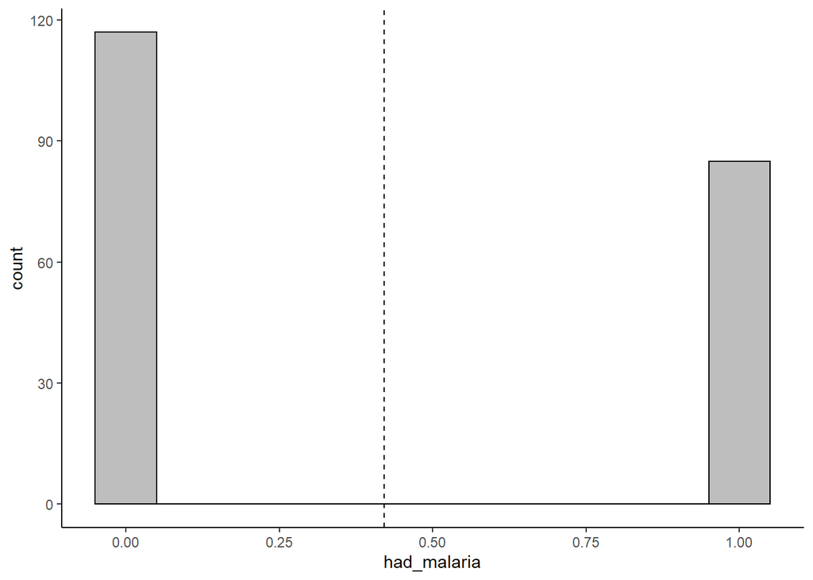

```r
count_mean <- mean(dt$had_malaria)
tab_mean <- mean(tab_dt$had_malaria)

count_var <- var(dt$had_malaria)
tab_var <- var(tab_dt$had_malaria)

ggplot(dt, aes(x = had_malaria)) + geom_histogram(col = "black", fill = "gray", binwidth = 0.1) +
  theme_classic() + geom_vline(xintercept = count_mean, lty = 2)
```

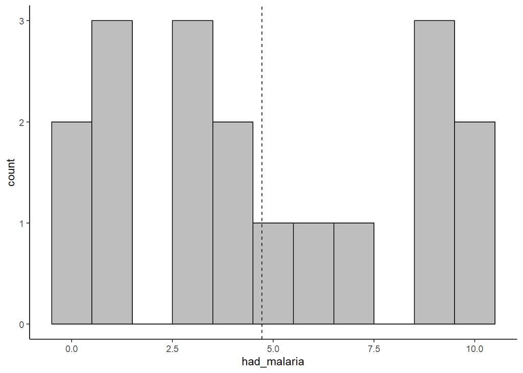

```r
ggplot(tab_dt, aes(x = had_malaria)) + geom_histogram(binwidth = 1, col = "black", fill = "gray") +
  theme_classic() + geom_vline(xintercept = tab_mean, lty = 2)
```

## 2.2 Calculate the crude incidence of malaria infections

```r
# I used the individual-level results but you should get the same if you used the tabulated ones.
incidence <- sum(dt$had_malaria) / sum(dt$time_to_first_malaria)
```

The incidence of malaria in this study population was 0.001 episodes per person-day, 1.43 episodes per 1000 person-days, 0.521 episodes per person-year.

## 2.3 Use glm() to fit a Poisson regression for incidence

First model is individual level (not shown)

```r
mod_pois <- glm(had_malaria ~ offset(log(time_to_first_malaria)), family = "poisson", data = dt)
#print_md(model_parameters(mod_pois, exponentiate = T))
```

Second model is tabulated data

```r
modt_pois <- glm(had_malaria ~ offset(log(time_to_first_malaria)), family = "poisson", data = tab_dt)
print_md(model_parameters(modt_pois, exponentiate = T))
```

| Parameter | IRR | SE | 95% CI | z | p |
| --- | --- | --- | --- | --- | --- |
| (Intercept) | 1.43e-03 | 1.55e-04 | (1.15e-03, 1.77e-03) | -60.41 | < .001 |

The incidence of first malaria in this model is the same as when calculated by hand (reassuring!). It was 1.43 episodes of malaria per 1000 person-days.

## 2.4 Add covariates `sexo`, `helmintosentrada`, `socioeconomico` to the model. Are any of the IRRs statistically significant?

Individual level (not shown)

```r
mod_pois2 <- glm(had_malaria ~ offset(log(time_to_first_malaria)) +
                   helminth_entrance + sexo + socioeconomico, family = "poisson", data = dt)
print_md(model_parameters(mod_pois2, exponentiate = T))
```

Tabulated data

```r
modt_pois2 <- glm(had_malaria ~ offset(log(time_to_first_malaria)) +
                   helminth_entrance + sexo + socioeconomico, family = poisson, data = tab_dt)
print_md(model_parameters(modt_pois2, exponentiate = T))
```

| Parameter | IRR | SE | 95% CI | z | p |
| --- | --- | --- | --- | --- | --- |
| (Intercept) | 1.91e-03 | 5.06e-04 | (1.11e-03, 3.13e-03) | -23.68 | < .001 |
| helminth entrance (Yes) | 1.58 | 0.40 | (0.97, 2.61) | 1.81 | 0.070 |
| sexo (masculino) | 0.72 | 0.18 | (0.44, 1.18) | -1.31 | 0.189 |
| socioeconomico (middle) | 0.90 | 0.24 | (0.52, 1.52) | -0.40 | 0.688 |
| socioeconomico (rich) | 0.73 | 0.28 | (0.33, 1.47) | -0.82 | 0.411 |

No predictors (covariates) are statistically associated with malaria in this population in this model.

## 2.5 Explore what happens when length of person-time is shortened. Reduce person-time among children with helmintosentrada = yes by 30%. What is the new IRR? Did this change the estimates as you expected?

```r
dt[, adjusted_person_time := ifelse(helminth_entrance == "Yes",
                                    time_to_first_malaria * 0.7, time_to_first_malaria)]
tab_dt[, adjusted_person_time := ifelse(helminth_entrance == "Yes",
                                        time_to_first_malaria * 0.7, time_to_first_malaria)]
```

This question is confusing. It says to include `sexo` but it also asks you to compare to the previous model.

First model has only `helmintosentrado` and `sexo` and the second model has `socioeconomico`, too.

```r
mod_pois3 <- glm(had_malaria ~ offset(log(adjusted_person_time)) + helminth_entrance + sexo,
                 family = "poisson", data = tab_dt)
print_md(model_parameters(mod_pois3, exponentiate = T))
```

| Parameter | IRR | SE | 95% CI | z | p |
| --- | --- | --- | --- | --- | --- |
| (Intercept) | 1.76e-03 | 4.09e-04 | (1.08e-03, 2.71e-03) | -27.27 | < .001 |
| helminth entrance (Yes) | 2.25 | 0.57 | (1.38, 3.72) | 3.22 | 0.001 |
| sexo (masculino) | 0.72 | 0.18 | (0.44, 1.17) | -1.34 | 0.181 |

```r
modt_pois4 <- glm(had_malaria ~ offset(log(adjusted_person_time)) + helminth_entrance + sexo + socioeconomico,
                 family = "poisson", data = tab_dt)
print_md(model_parameters(modt_pois4, exponentiate = T))
```

| Parameter | IRR | SE | 95% CI | z | p |
| --- | --- | --- | --- | --- | --- |
| (Intercept) | 1.91e-03 | 5.06e-04 | (1.11e-03, 3.13e-03) | -23.68 | < .001 |
| helminth entrance (Yes) | 2.26 | 0.57 | (1.38, 3.73) | 3.23 | 0.001 |
| sexo (masculino) | 0.72 | 0.18 | (0.44, 1.18) | -1.31 | 0.189 |
| socioeconomico (middle) | 0.90 | 0.24 | (0.52, 1.52) | -0.40 | 0.688 |
| socioeconomico (rich) | 0.73 | 0.28 | (0.33, 1.47) | -0.82 | 0.411 |

After adjusting the person-time among children with helminth infection at study entrance, the IRR is now 2.26 and significantly associated with the incidence of first malaria in this study population. This follows my intuition. The unadjusted incidence of first malaria was already greater in children with helminth infection at study start than children without helminth infection. If we artifically decrease the denominator of this group of children, that would make the incidence in this group greater, therefore leading to a higher IRR compared to children without helminth infection at study start.